# (1987-Flight Delay Analysis)

##### Obviously December is the most month involved with delayed arrival flights

**Figuring the relation between carrier type and delayed departures and arrivals (Regardless the amount of delay)**

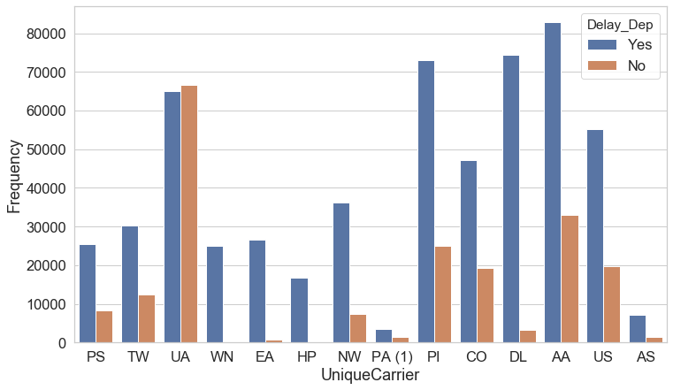

```python
plt.figure(figsize=(12,7))
sb.countplot(data=df2,x='UniqueCarrier',hue='Delay_Dep')
plt.ylabel('Frequency')
plt.xlabel('UniqueCarrier');
plt.title('Carrier Type Vs. Departure Delay',fontsize=20, fontweight=0, color='purple', style='italic');
```

##### AA, DL, and PI are the most unique carrier involved with delayed departure flights

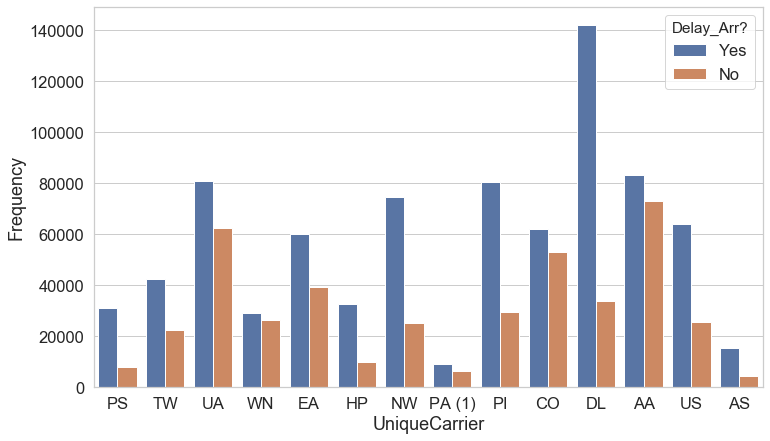

```python
plt.figure(figsize=(12,7))
sb.countplot(data=df2,x='UniqueCarrier',hue='Delay_Arr')
plt.ylabel('Frequency')
plt.xlabel('UniqueCarrier');
plt.title('Carrier Type Vs. Arrival Delay',fontsize=20, fontweight=0, color='purple', style='italic');
```

##### DL is the most unique carrier involved with delayed arrival flights

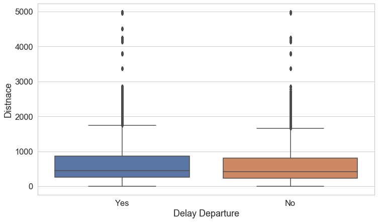

```python
# plotting delay_dep and distance
plt.figure(figsize=(12,7))
sb.boxplot(data=df2,x='Delay_Dep',y='Distance')
plt.ylabel('Distnace')
plt.xlabel('Delay Departure');
plt.title('Distance Vs. Departure Delay',fontsize=20, fontweight=0, color='purple', style='italic');
```

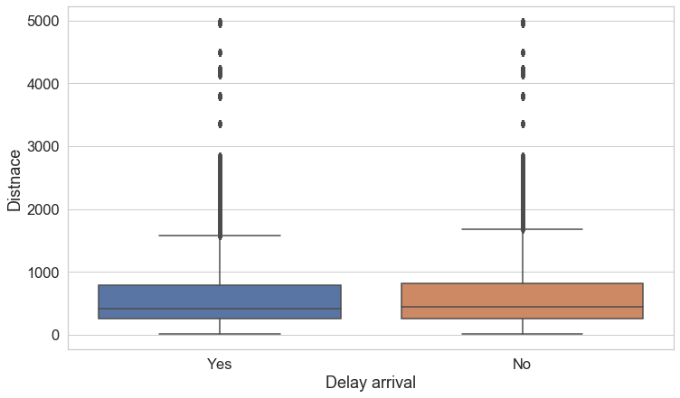

```python
# plotting delay_arrival and distance
plt.figure(figsize=(12,7))
sb.boxplot(data=df2,x='Delay_Arr',y='Distance')
plt.ylabel('Distnace')
plt.xlabel('Delay arrival');
plt.title('Carrier Type Vs. Departure Delay',fontsize=20, fontweight=0, color='purple', style='italic');
```

##### Obviously we can see the long flight distances are more prone to delay at the departure

## Multivariate Exploration

> Create plots of three or more variables to investigate your data even further. Make sure that your investigations are justified, and follow from your work in the previous sections.

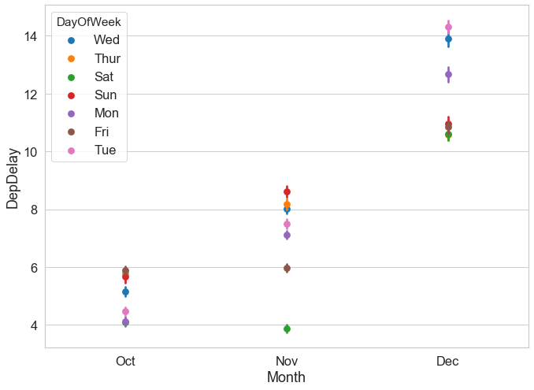

```python
# plotting Month, DepDelay, and Day of week in a pointplot
sb.pointplot(data =df2, x = 'Month', y = 'DepDelay',
           palette = 'tab10', linestyles = '',hue='DayOfWeek');

plt.title('Month Vs. Departure Delay and Day of week ',fontsize=20, fontweight=0, color='purple', style='italic');
```

##### We can see that days involved with highest amount of time delay in departure are different in each month ; we reconfirmed that december has the most amount of delayed departure times specifically in Tuesday, Wednesday, and mondays

##### In November Sunday, Thursday, and Wednesdays

##### In October Friday, Thursday, and Sundays

**Plotting Month, Distance, and Delay_Dep(cateogrial), to see which month has the most delayed flights according to distance**

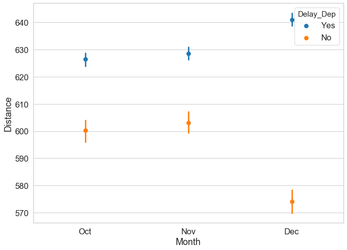

```python
sb.pointplot(data =df2, x = 'Month', y = 'Distance',
           palette = 'tab10', linestyles = '',hue='Delay_Dep');
plt.title('Month Vs. Departure Delay and Distance ',fontsize=20, fontweight=0, color='purple', style='italic');
```

###### We can see that the longer distances flights happened in December with the most delayed flights number

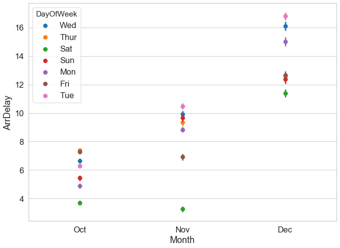

```python
#plotting Month, ArrDelay, and Day of week in a pointplot
sb.pointplot(data =df2, x = 'Month', y = 'ArrDelay',
           palette = 'tab10', linestyles = '',hue='DayOfWeek');
plt.title('Month Vs. Arrival Delay and Day of week ',fontsize=20, fontweight=0, color='purple', style='italic');
```

##### We can see that days involved with highest amount of time delay in arrival are different in each month ; we reconfirmed that December has the most amount of delayed departure times specifically in Tuesday, Wednesday, and Mondays